# Lab week 3 - Binary classification

Data Science and Machine Learning 1 - CEU 2018

Jeno Pal

2018-01-23

In binary classification the goal is to predict a *binary outcome* that is either positive or negative. This is a general term, it is important to know what’s what.

```r
rm(list=ls())
library(ggplot2)
library(data.table)
library(caret)
library(glmnet)
library(ROCR)
library(e1071)
theme_set(theme_bw())
```

## Data: medical appointment no-shows

```r
# https://www.kaggle.com/joniarroba/noshowappointments
data <- fread("../../data/medical-appointments-no-show/no-show-data.csv")
str(data)
```

```
Classes ‘data.table’ and 'data.frame':  110527 obs. of  14 variables:
 $ PatientId     : num  2.99e+13 5.59e+14 4.26e+12 8.68e+11 8.84e+12 ...
 $ AppointmentID : int  5642903 5642503 5642549 5642828 5642494 5626772 5630279 5630575 5638447 5629123 ...
 $ Gender        : chr  "F" "M" "F" "F" ...
 $ ScheduledDay  : chr  "2016-04-29T18:38:08Z" "2016-04-29T16:08:27Z" "2016-04-29T16:19:04Z" "2016-04-29T17:29:31Z" ...
 $ AppointmentDay: chr  "2016-04-29T00:00:00Z" "2016-04-29T00:00:00Z" "2016-04-29T00:00:00Z" "2016-04-29T00:00:00Z" ...
 $ Age           : int  62 56 62 8 56 76 23 39 21 19 ...
 $ Neighbourhood : chr  "JARDIM DA PENHA" "JARDIM DA PENHA" "MATA DA PRAIA" "PONTAL DE CAMBURI" ...
 $ Scholarship   : int  0 0 0 0 0 0 0 0 0 0 ...
 $ Hipertension  : int  1 0 0 0 1 1 0 0 0 0 ...
 $ Diabetes      : int  0 0 0 0 1 0 0 0 0 0 ...
 $ Alcoholism    : int  0 0 0 0 0 0 0 0 0 0 ...
 $ Handcap       : int  0 0 0 0 0 0 0 0 0 0 ...
 $ SMS_received  : int  0 0 0 0 0 0 0 0 0 0 ...
 $ No-show       : chr  "No" "No" "No" "No" ...
 - attr(*, ".internal.selfref")=<externalptr>
```

```r
# some data cleaning
data[, c("PatientId", "AppointmentID", "Neighbourhood") := NULL]
setnames(data,
         c("No-show",
           "Age",
           "Gender",
           "ScheduledDay",
           "AppointmentDay",
           "Scholarship",
           "Hipertension",
           "Diabetes",
           "Alcoholism",
           "Handcap",
           "SMS_received"),
         c("no_show",
           "age",
           "gender",
           "scheduled_day",
           "appointment_day",
           "scholarship",
           "hypertension",
           "diabetes",
           "alcoholism",
           "handicap",
           "sms_received"))
# clean up a little bit
data <- data[age %between% c(0, 95)]
# for binary prediction with caret, the target variable must be a factor
data[, no_show := factor(no_show, levels = c("Yes", "No"))] # making it a factr is necessary because of using caret
data[, no_show_num := ifelse(no_show == "Yes", 1, 0)]
data[, handicap := ifelse(handicap > 0, 1, 0)]
# create new variables
data[, scheduled_day := as.Date(scheduled_day)]
data[, appointment_day := as.Date(appointment_day)]
data[, days_since_scheduled := as.integer(appointment_day - scheduled_day)]
data <- data[days_since_scheduled > -1]
```

### Some descriptives

#### Age

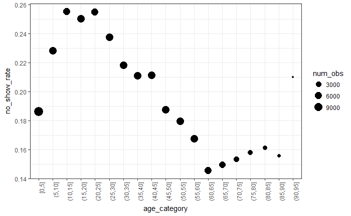

```r
data_by_age <- data[ ,
  .(no_show_rate = mean(no_show_num), num_obs = .N),
  keyby = .(age_category = cut(age, breaks = seq(0, 100, by = 5), include.lowest = TRUE))]
ggplot(data = data_by_age, aes(x = age_category, y = no_show_rate, size = num_obs)) +
  geom_point() +
  theme(axis.text.x = element_text(angle = 90, hjust = 1))
```

#### Days since scheduled

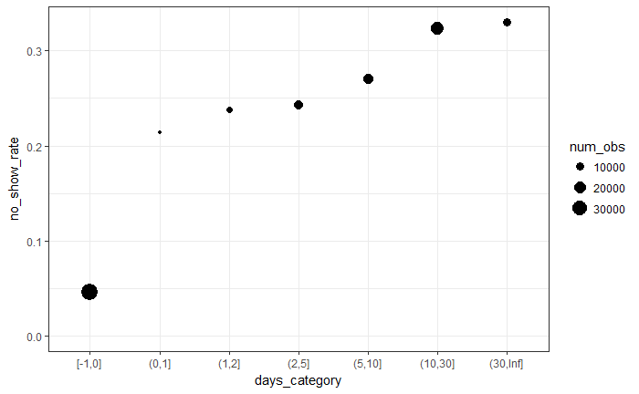

```r
data_by_days_since_scheduled <- data[ ,
  .(no_show_rate = mean(no_show_num), num_obs = .N),
  keyby = .(days_category = cut(days_since_scheduled, breaks = c(-1, 0, 1, 2, 5, 10, 30, Inf), include.lowest = TRUE))]
ggplot(data = data_by_days_since_scheduled,
       aes(x = days_category, y = no_show_rate, size = num_obs)) +
  geom_point() +
  ylim(0, NA)
```

```r
knitr::kable(data[, .(share_no_show = mean(no_show_num)), keyby = "gender"])
```

| gender | share_no_show |
| --- | --- |
| F | 0.2031365 |
| M | 0.1996587 |

```r
# scholarship is indicative of socio-economic status
knitr::kable(data[, .(share_no_show = mean(no_show_num)), keyby = "scholarship"])
```

| scholarship | share_no_show |
| --- | --- |
| 0 | 0.1980545 |
| 1 | 0.2373630 |

```r
knitr::kable(data[, .(share_no_show = mean(no_show_num)), keyby = "sms_received"])
```

| sms_received | share_no_show |
| --- | --- |
| 0 | 0.1669800 |
| 1 | 0.2757765 |

```r
data[, no_show_num := NULL]
data[, days_category := cut(
  days_since_scheduled,
  breaks = c(-1, 0, 1, 2, 5, 10, 30, Inf),
  include.lowest = TRUE)]
data[, age_category := cut(age,
                           breaks = seq(0, 100, by = 5),
                           include.lowest = TRUE)]
```

Now create a training and a test data and estimate a simple logistic regression to predict `no_show`.

```r
# set up training and test data
# model selection will be done via cross-validation
training_ratio <- 0.5
set.seed(1234)
train_indices <- createDataPartition(y = data[["no_show"]],
                                     times = 1,
                                     p = training_ratio,
                                     list = FALSE)
data_train <- data[train_indices, ]
data_test <- data[-train_indices, ]
```

```r
# start simple: estimate logistic regression
# CV: only for later comparisons
train_control <- trainControl(method = "cv",
                              number = 5,
                              classProbs = TRUE) # means i am looking for binary probabilities
set.seed(857)
glm_model <- train(no_show ~ age_category,
                   method = "glm",
                   data = data_train,
                   trControl = train_control)
test_prediction <- predict.train(glm_model, newdata = data_test)
test_truth <- data_test[["no_show"]]
```

## Errors in binary classification - the confusion matrix

There are 4 cases:

- true positives: those that are positive in reality and we correctly predict them to be positive
- false positives: those that are negative in reality and we falsely predict them to be positive
- true negatives: those that are negative in reality and we correctly predict them to be negative
- false negatives: those that are positive in reality and we falsely predict them to be negative

```r
confusionMatrix(test_prediction, test_truth)
```

```
Confusion Matrix and Statistics

          Reference
Prediction   Yes    No
       Yes     0     0
       No  11153 44084

               Accuracy : 0.7981
                 95% CI : (0.7947, 0.8014)
    No Information Rate : 0.7981
    P-Value [Acc > NIR] : 0.5025

                  Kappa : 0
 Mcnemar's Test P-Value : <2e-16

            Sensitivity : 0.0000
            Specificity : 1.0000
         Pos Pred Value :    NaN
         Neg Pred Value : 0.7981
             Prevalence : 0.2019
         Detection Rate : 0.0000
   Detection Prevalence : 0.0000
      Balanced Accuracy : 0.5000

       'Positive' Class : Yes
```

No information rate: if you predict the biggest class for all samples, what would be the accuracy? It’s a benchmark. Is it a useful predictive model? Not really. Thus, accuracy is also not a super useful measure of a predictive model. The various types of errors have to be examined and we have to decide based on them.

```r
# obtain probabilities instead of binary predictions
test_prediction_probs <- predict.train(glm_model,
                                       newdata = data_test,
                                       type = "prob")
```

```
prediction from a rank-deficient fit may be misleading
```

```r
head(test_prediction_probs)
```

|  | Yes | No |
| --- | --- | --- |
| 1 | 0.1448425 | 0.8551575 |
| 2 | 0.1665355 | 0.8334645 |
| 3 | 0.1565495 | 0.8434505 |
| 4 | 0.2530120 | 0.7469880 |
| 5 | 0.2163350 | 0.7836650 |
| 6 | 0.2399116 | 0.7600884 |

```r
## for each row the sum is 1
## YES = the probability of not showing up
```

```r
summary(test_prediction_probs$Yes)
```

```
   Min. 1st Qu.  Median    Mean 3rd Qu.    Max.
 0.1338  0.1829  0.2121  0.2015  0.2289  0.2551
```

By default, predict.train uses the 50% threshold for prediction. However, it is not set into stone that we have to use it.

```r
test_prediction_v2 <- ifelse(test_prediction_probs$Yes > 0.20, "Yes", "No")
test_prediction_v2 <- factor(test_prediction_v2, levels = c("Yes", "No"))
confusionMatrix(test_prediction_v2, test_truth)
```

```
Confusion Matrix and Statistics

          Reference
Prediction   Yes    No
       Yes  6469 21449
       No   4684 22635

               Accuracy : 0.5269
                 95% CI : (0.5227, 0.5311)
    No Information Rate : 0.7981
    P-Value [Acc > NIR] : 1

                  Kappa : 0.0599
 Mcnemar's Test P-Value : <2e-16

            Sensitivity : 0.5800
            Specificity : 0.5135
         Pos Pred Value : 0.2317
         Neg Pred Value : 0.8285
             Prevalence : 0.2019
         Detection Rate : 0.1171
   Detection Prevalence : 0.5054
      Balanced Accuracy : 0.5467

       'Positive' Class : Yes
```

```r
## this is better now because I finally have true positives and false negatives are lower now, but accuracy is lower too
```

## Varying thresholds

```r
thresholds <- seq(0.1, 0.3, by = 0.05)
for (thr in thresholds) {
  test_prediction <- ifelse(test_prediction_probs$Yes > thr, "Yes", "No")
  test_prediction <- factor(test_prediction, levels = c("Yes", "No"))
  print(paste("Threshold:", thr))
  print(confusionMatrix(test_prediction, test_truth)[["table"]])
}
```

```
[1] "Threshold: 0.1"
          Reference
Prediction   Yes    No
       Yes 11153 44084
       No      0     0
[1] "Threshold: 0.15"
          Reference
Prediction   Yes    No
       Yes 10004 37971
       No   1149  6113
[1] "Threshold: 0.2"
          Reference
Prediction   Yes    No
       Yes  6469 21449
       No   4684 22635
[1] "Threshold: 0.25"
          Reference
Prediction   Yes    No
       Yes  2506  7415
       No   8647 36669
[1] "Threshold: 0.3"
          Reference
Prediction   Yes    No
       Yes     0     0
       No  11153 44084
```

What to choose then? It depends on which type of error you deem as more important. Medical appointment problem: probably it is not too costly to send notifications to those who are likely to miss the appointment. Thus, false positives may matter less than false negatives.

## The ROC curve

The ROC curve summarizes how a binary classifier performs “overall”, taking into accounts all possible thresholds. It shows the trade-off between true positive rate (a.k.a sensitivity, # true positives / # all positives) and the false positive rate (a.k.a 1 - specificity, # false positive / # negatives).

```r
thresholds <- seq(0.1, 0.3, by = 0.05)
true_positive_rates <- rep(0, length(thresholds))
false_positive_rates <- rep(0, length(thresholds))
for (ix in 1:length(thresholds)) {
  thr <- thresholds[ix]
  test_prediction <- ifelse(test_prediction_probs$Yes > thr, "Yes", "No")
  test_prediction <- factor(test_prediction, levels = c("Yes", "No"))
  cm <- as.matrix(confusionMatrix(test_prediction, test_truth))
  true_positive_rates[ix] <- cm[1, 1] / (cm[1, 1] + cm[2, 1])
  false_positive_rates[ix] <- cm[1, 2] / (cm[1, 2] + cm[2, 2])
}
```

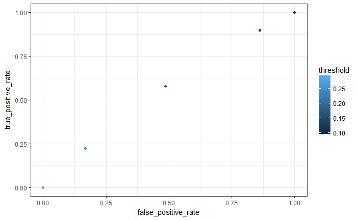

```r
manual_roc <- data.table("threshold" = thresholds,
                         "true_positive_rate" = true_positive_rates,
                         "false_positive_rate" = false_positive_rates)
ggplot(data = manual_roc,
       aes(x = false_positive_rate,
           y = true_positive_rate,
           color = threshold)) +
  geom_point()
```

One point corresponds to one threshold and shows the trade-off between the two types of errors one makes by using the classifier with that particular threshold.

Draw the whole line, for **all** thresholds:

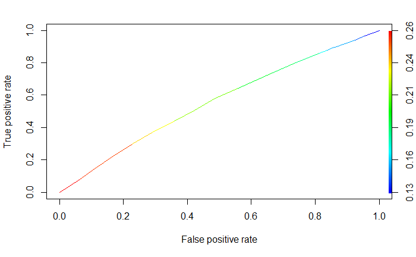

```r
rocr_prediction <- prediction(test_prediction_probs$Yes,
                              data_test[["no_show"]])
# built-in plot method
plot(performance(rocr_prediction, "tpr", "fpr"), colorize=TRUE)
```

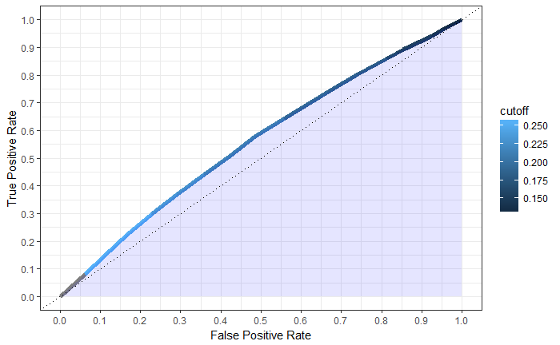

```r
# a ggplot version
# using prediction function from ROCR package
glm_prediction <- prediction(test_prediction_probs$Yes,
                              data_test[["no_show"]])
glm_perf <- performance(glm_prediction, measure = "tpr", x.measure = "fpr")
glm_roc_df <- data.table(
  model = "glm",
  FPR = glm_perf@x.values[[1]],
  TPR = glm_perf@y.values[[1]],
  cutoff = glm_perf@alpha.values[[1]]
)
ggplot(glm_roc_df) +
  geom_line(aes(FPR, TPR, color = cutoff), size = 2) +
  geom_ribbon(aes(FPR, ymin = 0, ymax = TPR), fill = "blue", alpha = 0.1) +
  geom_abline(intercept = 0, slope = 1,  linetype = "dotted", col = "black") +
  scale_y_continuous(limits = c(0, 1), breaks = seq(0, 1, .1)) +
  scale_x_continuous(limits = c(0, 1), breaks = seq(0, 1, .1)) +
  xlab("False Positive Rate") + ylab("True Positive Rate")
```

Perfect classifier: North-western corner. Coin-flip classifier: 45-degree line.

## AUC

AUC is the “area under the (ROC) curve”. This is a number between 0 and 1. **Interpretation: if we take a random positive and a random negative case, AUC shows the probability that the classifier assigns a higher score to the positive case than to the negative** (see my blogpost [here](https://jenopal.netlify.com/2017/12/31/interpretation-on-roc-auc/)).

Higher AUC generally means better classification.

```r
# calculate AUC
AUC <- performance(rocr_prediction, "auc")@y.values[[1]]
print(AUC)
```

```
[1] 0.5573239
```

We can set AUC as a measure for selecting between hyperparameters or selecting between models: it can be calculated for each hold-out sample in a cross validation procedure, for example.

```r
# glmnet example for cross-validation, hold-out set AUCs
train_control <- trainControl(method = "cv",
                              number = 5,
                              classProbs = TRUE,
                              verboseIter = TRUE,
                              summaryFunction = twoClassSummary) # necessary!
tune_grid <- expand.grid("alpha" = c(0, 1),
                         "lambda" = c(0.01, 0.001, 0.0001))
set.seed(857)
glmnet_model <- train(no_show ~ days_category +
                                poly(age, 3) +
                                scholarship +
                                gender +
                                alcoholism +
                                diabetes,
                      data = data_train,
                      method = "glmnet",
                      preProcess = c("center", "scale"),
                      trControl = train_control,
                      tuneGrid = tune_grid,
                      metric = "ROC")  # set it to ROC to choose models based on AUC
glmnet_model
```

```
glmnet

55238 samples
    6 predictor
    2 classes: 'Yes', 'No'

Pre-processing: centered (13), scaled (13)
Resampling: Cross-Validated (5 fold)
Summary of sample sizes: 44191, 44190, 44190, 44190, 44191
Resampling results across tuning parameters:

  alpha  lambda  ROC        Sens          Spec
  0      1e-04   0.7271374  0.0003585836  0.9999773
  0      1e-03   0.7271374  0.0003585836  0.9999773
  0      1e-02   0.7270735  0.0000000000  1.0000000
  1      1e-04   0.7271420  0.0009862255  0.9998639
  1      1e-03   0.7271326  0.0006276017  0.9999546
  1      1e-02   0.7209219  0.0000000000  1.0000000

ROC was used to select the optimal model using the largest value.
The final values used for the model were alpha = 1 and lambda = 1e-04.
```

```r
# finally, evaluate the best model on test set
test_prediction_glmnet <- predict.train(glmnet_model,
                                        newdata = data_test,
                                        type = "prob")
```

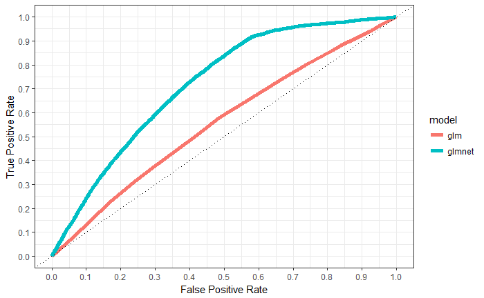

```r
# compare it to previous model
glmnet_prediction <- prediction(test_prediction_glmnet$Yes,
                                data_test[["no_show"]])
glmnet_perf <- performance(glmnet_prediction, measure = "tpr", x.measure = "fpr")
glmnet_roc_df <- data.table(
  model = "glmnet",
  FPR = glmnet_perf@x.values[[1]],
  TPR = glmnet_perf@y.values[[1]],
  cutoff = glmnet_perf@alpha.values[[1]]
)
roc_df <- rbind(glm_roc_df, glmnet_roc_df)
ggplot(roc_df) +
  geom_line(aes(FPR, TPR, color = model), size = 2) +
  geom_abline(intercept = 0, slope = 1,  linetype = "dotted", col = "black") +
  scale_y_continuous(limits = c(0, 1), breaks = seq(0, 1, .1)) +
  scale_x_continuous(limits = c(0, 1), breaks = seq(0, 1, .1)) +
  xlab("False Positive Rate") + ylab("True Positive Rate")
```

## Well-calibrated probabilities

Can the scores produced by the model be regarded as probabilities? Let’s calculate the predicted and actual share of positive cases for groups of observations in the test set based on their predicted scores.

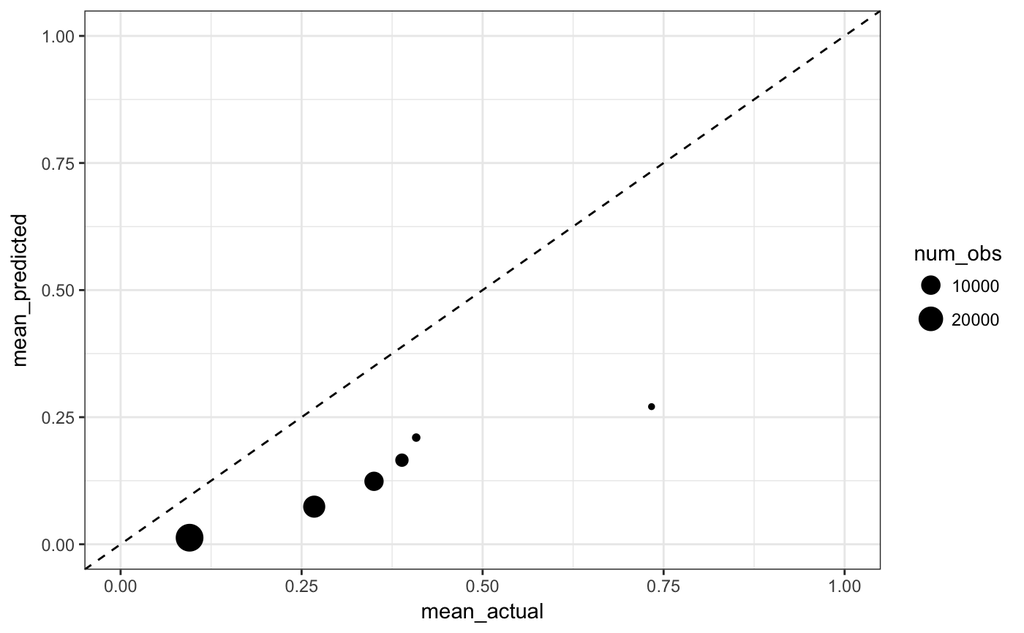